# Aula Prática - Matemática Instrumental

Lucas Mascarenhas Almeida

17 de abril de 2018

[figure not shown]

# A aula prática de Introdução ao R

## O que é o **R** ?

O [R](https://cran.r-project.org/) é uma linguagem de programação do tipo software livre bastante popular no meio acadêmico com foco em análises estatísticas e gráficas. A ferramenta possui facilidade, robustez e qualidade na produção das análises e gráficos, incluindo uma grande diversidade de pacotes que permitem que o usuário detenha total controle do que esta sendo produzido.

[figure not shown]

Para baixar o **R** e o **Rstudio** acesse:

- R: https://cran.r-project.org/
- Rstudio: https://www.rstudio.com/

### Pulo do gato!

[figure not shown]

Alguns sites e materiais que podem ser de grande utilidade pra quem está conhecendo o mundo do R:

- [Stack Overflow](https://stackoverflow.com/). Fundada em 2008, o Stack Overflow é a maior e mais confiável comunidade online voltada para programação.
- [Google’s R Style Guide](https://google.github.io/styleguide/Rguide.xml). O objetivo do Google’s R Style Guide é tornar o seu código em R mais fácil de ler, compartilhar e verificar.
- [Rpubs](https://rpubs.com/L_Mascarenhas/). Um ambiente para publicação de documentos a partir de R.
- [R-bloggers](https://www.r-bloggers.com/). Um site que reúne os blogueiros que escrevem sobre R.
- [R no Facebook](https://www.facebook.com/groups/1410023525939155/?ref=bookmarks). Comunidade do facebook (R Brasil - Programadores).
- [R for Data Science](http://r4ds.had.co.nz/). Livro que propõe ensinar o data science no R.

## Aula prática - Introdução ao **R**

### Primeiros Passos

- Estatística descritiva no R (Pacote Base): Funções estatísticas e representações gráficas.
- Importação de banco de dados (Pacote [**readxl**](https://www.rdocumentation.org/packages/readxl/versions/1.0.0)).

O primeiro passo é criar uma pasta exclusiva para o novo script e apontar esta pasta como o diretório de trabalho.

```r
# Apontando para a pasta de trabalho

setwd("C:/Users/lukas/codes_old/R - Codes/Aulas - ENGD02/Compilado")
```

Após criar o script, salvar na pasta dedicada ao projeto e apontar o diretório de trabalho, devemos instalar e chamar todos o pacotes que serão utilizados durante o desenvolvimento do código.

```r
# Chamando biblioteca, se ainda nao estiver instalada use, ex: install.packages("ggplot2")

if(!require("readxl")) install.packages("readxl") ; library(readxl)
if(!require("dplyr")) install.packages("dplyr") ; library(dplyr)
if(!require("ggplot2")) install.packages("ggplot2") ; library(ggplot2)
```

Com os procedimentos iniciais cumpridos, vamos para o desenvolvimento do código.

Funções da estatística descritiva:

```r
# Conceitos basicos----

# Criando um vetor

vetor = c(8, 10, 15, 35, 40, 3, 19, 10, 34, 7)

## Medidas de localizacao

media <- mean(vetor)
mediana <- median(vetor)
quartil <- quantile(vetor)
resumo <- summary(vetor)

## Medidas de variabilidade

desvio <- sd(vetor)
variancia <- var(vetor)
CV <- (desvio/media)*100
```

Importando banco de dados:

```r
# Importando banco de dados----

dados <- read_excel("C:/Users/lukas/codes_old/R - Codes/Aulas - ENGD02/Compilado/data/EconomistData.xlsx",col_types = c("text", "numeric", "numeric", "numeric", "text"))
```

Como foi apresentado em sala, em versões iguais ou superiores a do R 3.4.3 e do Rstudio 1.1.423 é possível importar um banco de dados do excel utilizando o atalho *import Dataset* que fica na aba *Environment*.

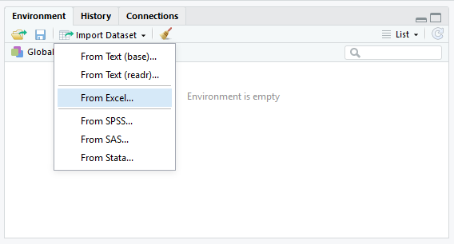

Também é possível importar um banco de dados do tipo csv ou txt através do atalho *import Dataset* que fica na aba *Environment*, basta selecionar a opção *From Text*.

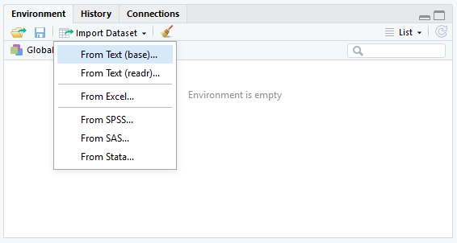

O banco de dados utilizado durante a aula apresenta o Índice de Desenvolvimento Humano (HDI) e o Índice de Percepção de Corrupção (CPI) para vários países. São dados do [Transparency International](https://www.transparency.org/).

Representação gráfica utilizando o pacote base.

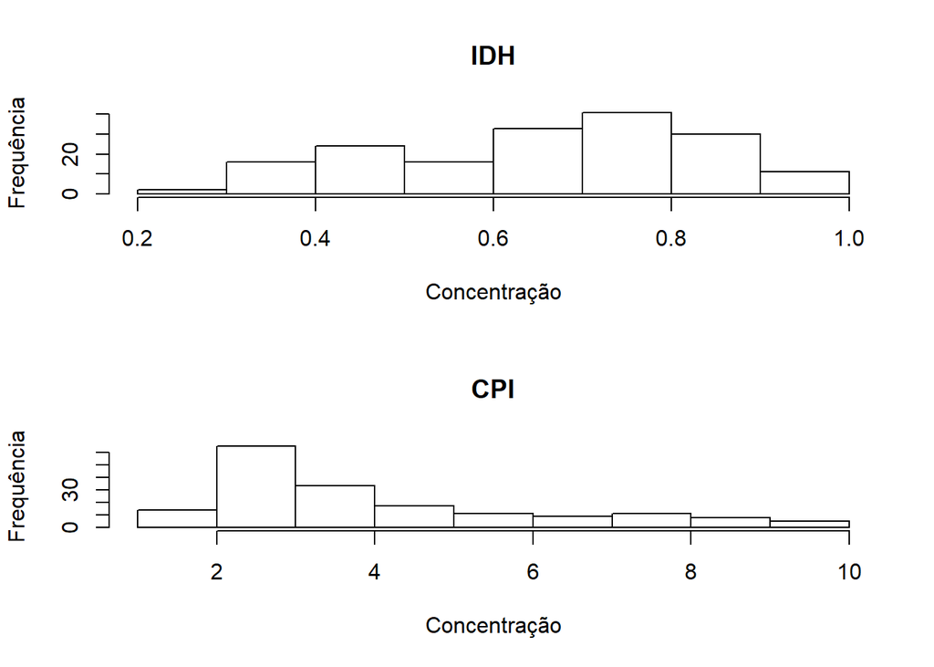

```r
# representacao grafica----

## Histograma

par(mfrow = c(2,1))

hist(dados$HDI, main = "IDH", xlab = "Concentração", ylab = "Frequência")
hist(dados$CPI, main = "CPI", xlab = "Concentração", ylab = "Frequência")
```

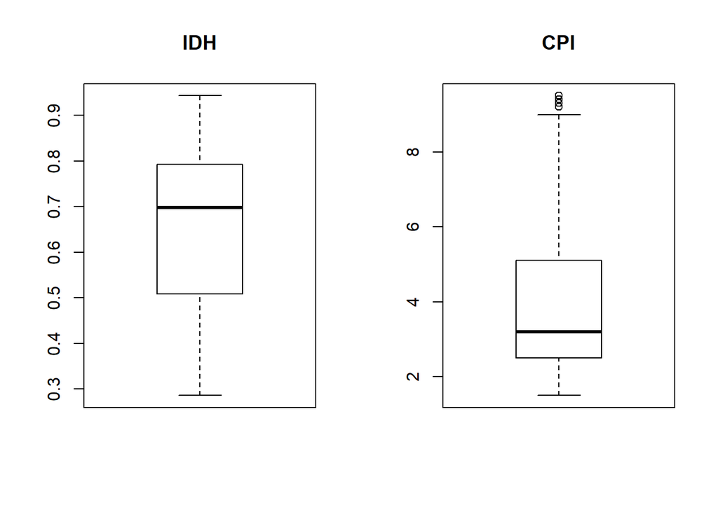

```r
## Box-plot

par(mfrow = c(1,2))

boxplot(dados$HDI, main = "IDH")
boxplot(dados$CPI, main = "CPI")
```

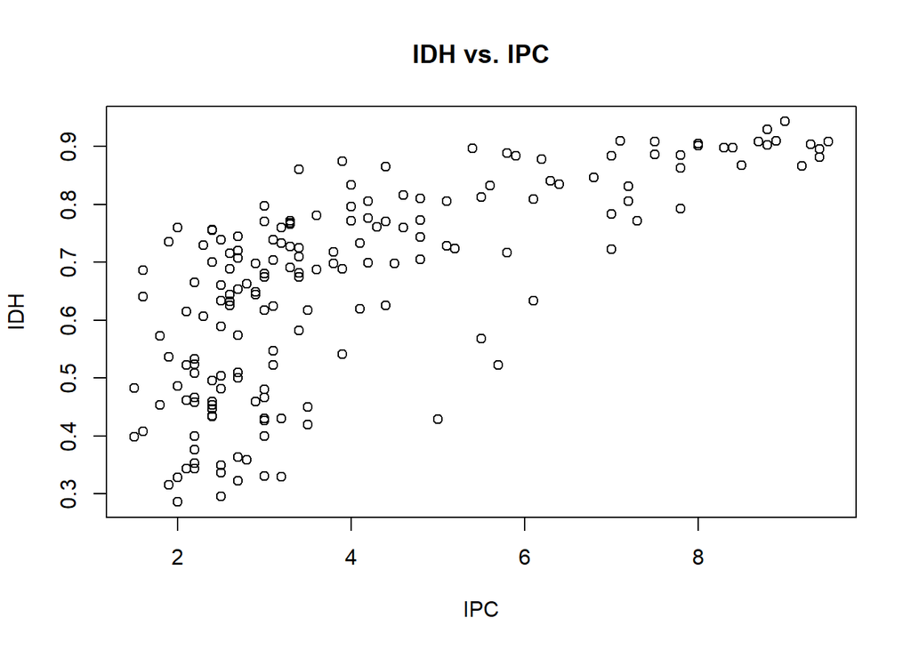

```r
## Dispersao

par(mfrow = c(1,1))

plot(dados$CPI, dados$HDI, main = "IDH vs. IPC", xlab = "IPC", ylab = "IDH", type = "p")
```

### Nova programação em R:

- Manipulação de dados (Pacote [**dplyr**](https://www.rdocumentation.org/packages/dplyr/versions/0.5.0)).
- Representação gráfica (Pacote [**ggplot2**](http://ggplot2.tidyverse.org/reference/)).

#### Manipulando e Exportando dados:

Manipulação do banco de dados é um grande desafio para quem trabalha com big data. O pacote [**dplyr**](https://www.rdocumentation.org/packages/dplyr/versions/0.5.0) apresenta algumas funções que otimizam as manipulações.

```r
# Manipulando e Exportando dados----

## Usando dplyr

dados_exp <- dados %>%
  group_by(Region) %>%
  mutate(M.CPI = mean(CPI), M.HDI = mean(HDI), Var.CPI = var(CPI)) %>%
  select(Region, M.CPI, M.HDI, Var.CPI, Country) %>%
  filter(M.CPI < 4.5)
```

Exportando dados:

```r
## Exportando dados

write.csv2(x = dados_exp, file = "dados_paises.csv")
```

#### Representação de dados:

O pacote [**ggplot2**](http://ggplot2.tidyverse.org/reference/) fornece um poderoso modelo de gráficos que facilita a produção de gráficos multi-camadas.

Gráfico de dispersão:

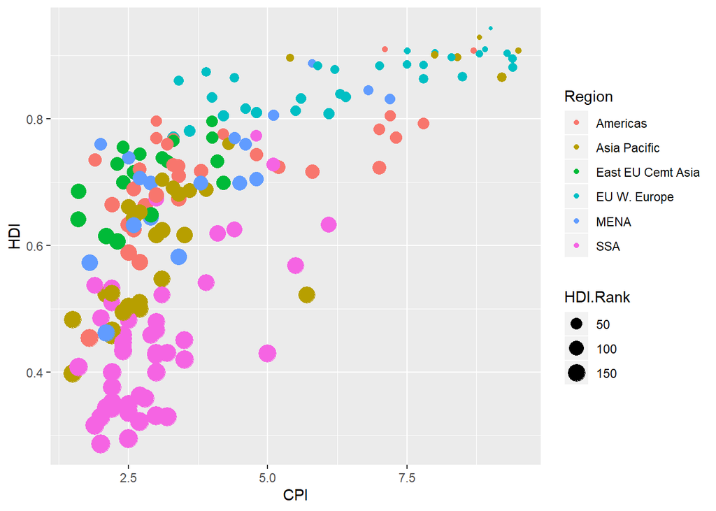

```r
# Representacao grafica (ggplot2)----

gg.1 <- ggplot(data = dados, mapping = aes(x = CPI, y = HDI)) +
  geom_point(mapping = aes(color = Region, size = HDI.Rank))

gg.1
```

Adicionando outras funções:

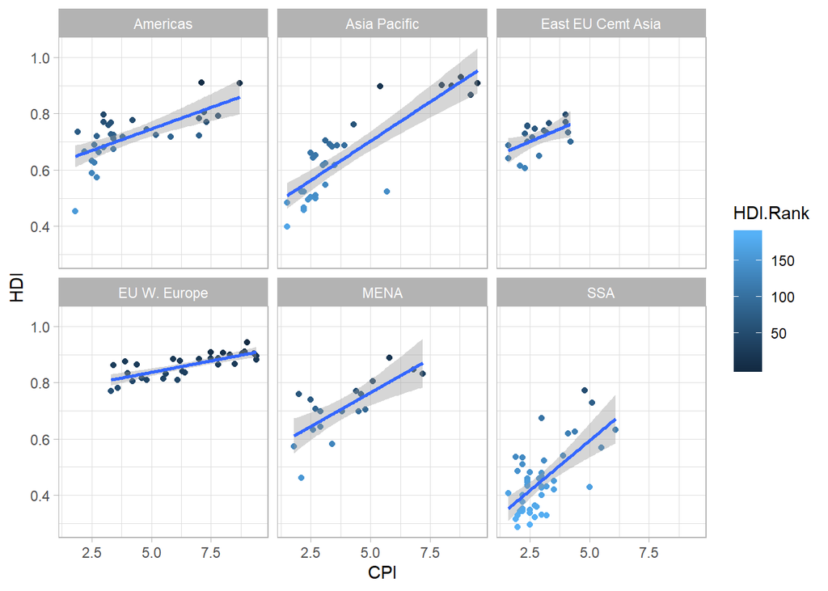

```r
gg.2 <- ggplot(data = dados, mapping = aes(x = CPI, y = HDI)) +
  geom_point(mapping = aes(color = HDI.Rank)) +
  facet_wrap(facets = ~Region, nrow = 2) +
  geom_smooth(method = "lm") +
  theme_light()

gg.2
```

Salvando os gráficos:

```r
# Salvando os graficos

ggsave(filename = "grafico1.png", plot = gg.1, width = 13, height = 7, dpi = 500)
```

### Script completo:

```r
# Apontando para a pasta de trabalho

setwd("C:/Users/lukas/codes_old/R - Codes/Aulas - ENGD02/Compilado")

# Chamando biblioteca, se ainda nao estiver instalada use, ex: install.packages("ggplot2")

if(!require("readxl")) install.packages("readxl") ; library(readxl)
if(!require("dplyr")) install.packages("dplyr") ; library(dplyr)
if(!require("ggplot2")) install.packages("ggplot2") ; library(ggplot2)

# Conceitos basicos----

# Criando um vetor

vetor = c(8, 10, 15, 35, 40, 3, 19, 10, 34, 7)

## Medidas de localizacao

media <- mean(vetor)
mediana <- median(vetor)
quartil <- quantile(vetor)
resumo <- summary(vetor)

## Medidas de variabilidade

desvio <- sd(vetor)
variancia <- var(vetor)
CV <- (desvio/media)*100

# Importando banco de dados----

dados <- read_excel("C:/Users/lukas/codes_old/R - Codes/Aulas - ENGD02/Compilado/data/EconomistData.xlsx",col_types = c("text", "numeric", "numeric", "numeric", "text"))

# representacao grafica----

## Histograma

par(mfrow = c(2,1))

hist(dados$HDI, main = "IDH", xlab = "Concentração", ylab = "Frequência")
hist(dados$CPI, main = "CPI", xlab = "Concentração", ylab = "Frequência")

## Box-plot

par(mfrow = c(1,2))

boxplot(dados$HDI, main = "IDH")
boxplot(dados$CPI, main = "CPI")

## Dispersao

par(mfrow = c(1,1))

plot(dados$CPI, dados$HDI, main = "IDH vs. IPC", xlab = "IPC", ylab = "IDH", type = "p")

# Manipulando e Exportando dados----

## Usando dplyr

dados_exp <- dados %>%
  group_by(Region) %>%
  mutate(M.CPI = mean(CPI), M.HDI = mean(HDI), Var.CPI = var(CPI)) %>%
  select(Region, M.CPI, M.HDI, Var.CPI, Country) %>%
  filter(M.CPI < 4.5)

## Exportando dados

write.csv2(x = dados_exp, file = "dados_paises.csv")

# Representacao grafica (ggplot2)----

gg.1 <- ggplot(data = dados, mapping = aes(x = CPI, y = HDI)) +
  geom_point(mapping = aes(color = Region, size = HDI.Rank))

gg.1

gg.2 <- ggplot(data = dados, mapping = aes(x = CPI, y = HDI)) +
  geom_point(mapping = aes(color = HDI.Rank)) +
  facet_wrap(facets = ~Region, nrow = 2) +
  geom_smooth(method = "lm") +
  theme_light()

gg.2

# Salvando os graficos

ggsave(filename = "grafico1.png", plot = gg.1, width = 13, height = 7, dpi = 500)
```

## Referências:

- http://www.estatisticacomr.uff.br/?p=176
- http://tutorials.iq.harvard.edu/R/Rgraphics/Rgraphics.html
- https://rpubs.com/bradleyboehmke/data_wrangling
- http://cyberhelp.sesync.org/data-manipulation-in-R-lesson/2016/07/26/